# Exercicio3

**1- Gere regras para os itemsets relativos à linha e coluna, nessa ordem, para todas as células da matriz abaixo. Por exemplo, 2→3, 2→5 e 2→7 para a primeira linha da matriz.**

|  | {2} | {3} | {5} | {7} |
| --- | --- | --- | --- | --- |
| {2} | X |  |  |  |
| {3} |  | X |  |  |
| {5} |  |  | X |  |
| {7} |  |  |  | X |

**Informar todas as regras com confiança mínima de 73%.**

|  | {2} | {3} | {5} | {7} |
| --- | --- | --- | --- | --- |
| {2} | X | 2→3 | 2→5 | 2→7 |
| {3} | 3→2 | X | 3→5 | 3→7 |
| {5} | 5→2 | 5→3 | X | 5→7 |
| {7} | 7→2 | 7→3 | 7→5 | X |

Todas as regras geradas irão apresentar a mesma confiança, visto que para cada regra {a→b}, sempre existira a regra {b→a}. Além disso para qualquer valor {a} existem 3 regras para {a} em sua linha e mais 3 regras para {a} em sua coluna. Desta forma todas regras apresentam a mesma confiança:

[figure not shown]

**2- Encontre os itemset(s) com um suporte de 33% e confiança de 100% do conjunto de transações abaixo:**

T1 = tree, cup, paper  
T2 = book, tomato, pen  
T3 = pen, book, tree  
T4 = tomato, pen, cup  
T5 = tree, paper, book  
T6 = pen, book

[figure not shown]

**3- Realize as seguintes atividades:**

**a) Utilize alguma implementação do Apriori, por exemplo, a da biblioteca mlxtend (python) ou do pacote Arules (R).**

```python
from mlxtend.frequent_patterns import apriori
from mlxtend.frequent_patterns import association_rules
from mlxtend.preprocessing import TransactionEncoder

import pandas as pd
import numpy as np
import seaborn as sb
import matplotlib.pyplot as plt
```

**b) Utilize os dados sobre compras de supermercado “supermercado.csv”, disponível no moodle.**

```python
import csv
from itertools import zip_longest

with open('supermercado.csv') as csvfile:
    rows = csv.reader(csvfile)
    res = [list(filter(None.__ne__, l)) for l in rows]
```

**c) Garanta que que um itemset não contenha dois itens iguais e que as regras mineradas contenham no consequente somente itens do tipo "bottled beer" ou "canned beer"**

```python
def verifyWordInCommon(a,b):
    newa = a.split()
    newb = b.split()
    for itema in newa:
        for itemb in newb:
            if(itemb == itema):
                return(True)

def removeCommonWords(lista):
    for item in lista:
        newlist = lista
        for newitem in lista:
            if(item == newitem):
                pass
            else:
                if(verifyWordInCommon(item, newitem)):
                    newlist.remove(newitem)
    return(newlist)

for sublist in res:
    sublist = removeCommonWords(sublist)
```

**d) Execute o Apriori com as configurações: suporte mínimo = 0.001 e confiança = 0.25. O que encontrou de interessante? Faça uma breve análise das regras e resultados encontrados.**

```python
te = TransactionEncoder()
encoded = te.fit(res).transform(res)
df = pd.DataFrame(encoded, columns=te.columns_)
df
```

|  | Instant food products | UHT-milk | abrasive cleaner | artif. sweetener | baby cosmetics | baby food | bags | baking powder | bathroom cleaner | beef | ... | turkey | vinegar | waffles | whipped/sour cream | whisky | white bread | white wine | whole milk | yogurt | zwieback |
| --- | --- | --- | --- | --- | --- | --- | --- | --- | --- | --- | --- | --- | --- | --- | --- | --- | --- | --- | --- | --- | --- |
| 0 | False | False | False | False | False | False | False | False | False | False | ... | False | False | False | False | False | False | False | False | False | False |
| 1 | False | False | False | False | False | False | False | False | False | False | ... | False | False | False | False | False | False | False | False | True | False |
| 2 | False | False | False | False | False | False | False | False | False | False | ... | False | False | False | False | False | False | False | True | False | False |
| 3 | False | False | False | False | False | False | False | False | False | False | ... | False | False | False | False | False | False | False | False | True | False |
| 4 | False | False | False | False | False | False | False | False | False | False | ... | False | False | False | False | False | False | False | True | False | False |
| ... | ... | ... | ... | ... | ... | ... | ... | ... | ... | ... | ... | ... | ... | ... | ... | ... | ... | ... | ... | ... | ... |
| 9830 | False | False | False | False | False | False | False | False | False | True | ... | False | False | False | True | False | False | False | True | False | False |
| 9831 | False | False | False | False | False | False | False | False | False | False | ... | False | False | False | False | False | False | False | False | False | False |
| 9832 | False | False | False | False | False | False | False | False | False | False | ... | False | False | False | False | False | False | False | False | True | False |
| 9833 | False | False | False | False | False | False | False | False | False | False | ... | False | False | False | False | False | False | False | False | False | False |
| 9834 | False | False | False | False | False | False | False | False | False | False | ... | False | True | False | False | False | False | False | False | False | False |

9835 rows × 169 columns

```python
frequent_itemsets = apriori(df, min_support=0.001, use_colnames=True)
frequent_itemsets
```

|  | support | itemsets |
| --- | --- | --- |
| 0 | 0.007626 | (Instant food products) |
| 1 | 0.033452 | (UHT-milk) |
| 2 | 0.003152 | (abrasive cleaner) |
| 3 | 0.003254 | (artif. sweetener) |
| 4 | 0.017692 | (baking powder) |
| ... | ... | ... |
| 8623 | 0.001830 | (tropical fruit, rolls/buns, whole milk, yogur... |
| 8624 | 0.001220 | (rolls/buns, whole milk, yogurt, whipped/sour ... |
| 8625 | 0.001017 | (tropical fruit, rolls/buns, whole milk, yogur... |
| 8626 | 0.001017 | (tropical fruit, sausage, whole milk, yogurt, ... |
| 8627 | 0.001118 | (tropical fruit, whole milk, yogurt, whipped/s... |

8628 rows × 2 columns

```python
dfRegras = association_rules(frequent_itemsets, metric='confidence', min_threshold=0.25)
dfRegras
```

|  | antecedents | consequents | antecedent support | consequent support | support | confidence | lift | leverage | conviction |
| --- | --- | --- | --- | --- | --- | --- | --- | --- | --- |
| 0 | (Instant food products) | (hamburger meat) | 0.007626 | 0.031520 | 0.002542 | 0.333333 | 10.575269 | 0.002302 | 1.452720 |
| 1 | (Instant food products) | (rolls/buns) | 0.007626 | 0.183935 | 0.002237 | 0.293333 | 1.594767 | 0.000834 | 1.154809 |
| 2 | (Instant food products) | (whole milk) | 0.007626 | 0.255313 | 0.002949 | 0.386667 | 1.514483 | 0.001002 | 1.214164 |
| 3 | (abrasive cleaner) | (root vegetables) | 0.003152 | 0.106253 | 0.001118 | 0.354839 | 3.339559 | 0.000784 | 1.385308 |
| 4 | (abrasive cleaner) | (whole milk) | 0.003152 | 0.255313 | 0.001423 | 0.451613 | 1.768862 | 0.000619 | 1.357959 |
| ... | ... | ... | ... | ... | ... | ... | ... | ... | ... |
| 8163 | (tropical fruit, whole milk, root vegetables, ... | (whipped/sour cream) | 0.004169 | 0.071581 | 0.001118 | 0.268293 | 3.748095 | 0.000820 | 1.268839 |
| 8164 | (whipped/sour cream, tropical fruit, whole mil... | (yogurt) | 0.001830 | 0.139502 | 0.001118 | 0.611111 | 4.380669 | 0.000863 | 2.212710 |
| 8165 | (whipped/sour cream, tropical fruit, root vege... | (whole milk) | 0.001627 | 0.255313 | 0.001118 | 0.687500 | 2.692777 | 0.000703 | 2.382999 |
| 8166 | (whipped/sour cream, whole milk, root vegetabl... | (tropical fruit) | 0.003457 | 0.085003 | 0.001118 | 0.323529 | 3.806115 | 0.000825 | 1.352605 |
| 8167 | (whipped/sour cream, tropical fruit, root vege... | (whole milk, yogurt) | 0.003355 | 0.056024 | 0.001118 | 0.333333 | 5.949788 | 0.000930 | 1.415963 |

8168 rows × 9 columns

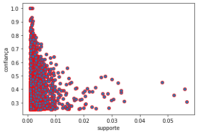

```python
plt.scatter(data = dfRegras, x='support', y='confidence', edgecolors='red')
plt.xlabel('supporte')
plt.ylabel('confiança')
plt.show()
```

```python
pd.set_option('display.max_rows', 10)
dfRegras.sort_values(by=['lift'],ascending=False)
```

|  | antecedents | consequents | antecedent support | consequent support | support | confidence | lift | leverage | conviction |
| --- | --- | --- | --- | --- | --- | --- | --- | --- | --- |
| 735 | (bottled beer, red/blush wine) | (liquor) | 0.004372 | 0.011083 | 0.001932 | 0.441860 | 39.868786 | 0.001883 | 1.771810 |
| 3126 | (white bread, ham) | (processed cheese) | 0.004982 | 0.013116 | 0.001627 | 0.326531 | 24.894795 | 0.001561 | 1.465373 |
| 733 | (liquor, bottled beer) | (red/blush wine) | 0.004575 | 0.018505 | 0.001932 | 0.422222 | 22.816239 | 0.001847 | 1.698741 |
| 3124 | (processed cheese, white bread) | (ham) | 0.003355 | 0.026029 | 0.001627 | 0.484848 | 18.626894 | 0.001540 | 1.890649 |
| 2250 | (curd, sugar) | (flour) | 0.003457 | 0.017387 | 0.001118 | 0.323529 | 18.607671 | 0.001058 | 1.452559 |
| ... | ... | ... | ... | ... | ... | ... | ... | ... | ... |
| 179 | (photo/film) | (whole milk) | 0.009253 | 0.255313 | 0.002339 | 0.252747 | 0.989952 | -0.000024 | 0.996567 |
| 218 | (seasonal products) | (whole milk) | 0.013320 | 0.255313 | 0.003355 | 0.251908 | 0.986666 | -0.000045 | 0.995449 |
| 256 | (zwieback) | (whole milk) | 0.006914 | 0.255313 | 0.001729 | 0.250000 | 0.979192 | -0.000037 | 0.992916 |
| 5136 | (bottled water, soda, shopping bags) | (whole milk) | 0.004067 | 0.255313 | 0.001017 | 0.250000 | 0.979192 | -0.000022 | 0.992916 |
| 7233 | (newspapers, rolls/buns, soda) | (whole milk) | 0.004067 | 0.255313 | 0.001017 | 0.250000 | 0.979192 | -0.000022 | 0.992916 |

8168 rows × 9 columns

Organizando os resultados a partir de seu valor de lift é possivel encontrar quais são as regras que são mais positivamente relacionadas. Fazendo uma breve análise dos dez primeiros resultados é possivel perceber que as principais regras implicam em produtos que normamente são utilizados juntos (em uma receita por exemplo), bem como produtos que são da mesma categoria (como no caso de {bottled beer, red/blush wine}→{liquor} onde todos são bebidas alcoólicas).